# kepler

```python
from keras.utils import np_utils
import matplotlib.pyplot as plt
import pandas as pd
import numpy as np
from imblearn.over_sampling import SMOTE

from sklearn.preprocessing import normalize
from sklearn.model_selection import train_test_split
from sklearn.metrics import *

#Keras is a high level neural networks library, based on either tensorflow or theano
from keras.models import Sequential, Model
from keras.layers import Conv1D, MaxPool1D, Dense, Dropout, Flatten, BatchNormalization
from keras.optimizers import Adam
```

Load datasets

```python
# define function to load train, test, and validation datasets
def load_dataset(path):

    print("Loading datasets...")
    df_train = pd.read_csv(path + 'exoTrain.csv', encoding = "ISO-8859-1")
    df_test = pd.read_csv(path + 'exoTest.csv', encoding = "ISO-8859-1")
    print("Loaded datasets!")
    return df_train, df_test

# load train, and test datasets
df_train, df_test = load_dataset('input/')
```

```
Loading datasets...
Loaded datasets!
```

The data set uses 2 for confirmed exoplants and 1 for non-exoplanets so convert these to 1 and 0

```python
df_train['LABEL'] = df_train['LABEL'].replace([1], [0])
df_train['LABEL'] = df_train['LABEL'].replace([2], [1])
df_test['LABEL'] = df_test['LABEL'].replace([1], [0])
df_test['LABEL'] = df_test['LABEL'].replace([2], [1])
```

## Print first 40 rows in training data set dataset

```python
display(df_train.head(n=40))
```

|  | LABEL | FLUX.1 | FLUX.2 | FLUX.3 | FLUX.4 | FLUX.5 | FLUX.6 | FLUX.7 | FLUX.8 | FLUX.9 | ... | FLUX.3188 | FLUX.3189 | FLUX.3190 | FLUX.3191 | FLUX.3192 | FLUX.3193 | FLUX.3194 | FLUX.3195 | FLUX.3196 | FLUX.3197 |
| --- | --- | --- | --- | --- | --- | --- | --- | --- | --- | --- | --- | --- | --- | --- | --- | --- | --- | --- | --- | --- | --- |
| 0 | 1 | 93.85 | 83.81 | 20.10 | -26.98 | -39.56 | -124.71 | -135.18 | -96.27 | -79.89 | ... | -78.07 | -102.15 | -102.15 | 25.13 | 48.57 | 92.54 | 39.32 | 61.42 | 5.08 | -39.54 |
| 1 | 1 | -38.88 | -33.83 | -58.54 | -40.09 | -79.31 | -72.81 | -86.55 | -85.33 | -83.97 | ... | -3.28 | -32.21 | -32.21 | -24.89 | -4.86 | 0.76 | -11.70 | 6.46 | 16.00 | 19.93 |
| 2 | 1 | 532.64 | 535.92 | 513.73 | 496.92 | 456.45 | 466.00 | 464.50 | 486.39 | 436.56 | ... | -71.69 | 13.31 | 13.31 | -29.89 | -20.88 | 5.06 | -11.80 | -28.91 | -70.02 | -96.67 |
| 3 | 1 | 326.52 | 347.39 | 302.35 | 298.13 | 317.74 | 312.70 | 322.33 | 311.31 | 312.42 | ... | 5.71 | -3.73 | -3.73 | 30.05 | 20.03 | -12.67 | -8.77 | -17.31 | -17.35 | 13.98 |
| 4 | 1 | -1107.21 | -1112.59 | -1118.95 | -1095.10 | -1057.55 | -1034.48 | -998.34 | -1022.71 | -989.57 | ... | -594.37 | -401.66 | -401.66 | -357.24 | -443.76 | -438.54 | -399.71 | -384.65 | -411.79 | -510.54 |
| 5 | 1 | 211.10 | 163.57 | 179.16 | 187.82 | 188.46 | 168.13 | 203.46 | 178.65 | 166.49 | ... | -98.45 | 30.34 | 30.34 | 29.62 | 28.80 | 19.27 | -43.90 | -41.63 | -52.90 | -16.16 |
| 6 | 1 | 9.34 | 49.96 | 33.30 | 9.63 | 37.64 | 20.85 | 4.54 | 22.42 | 10.11 | ... | -58.56 | 9.93 | 9.93 | 23.50 | 5.28 | -0.44 | 10.90 | -11.77 | -9.25 | -36.69 |
| 7 | 1 | 238.77 | 262.16 | 277.80 | 190.16 | 180.98 | 123.27 | 103.95 | 50.70 | 59.91 | ... | -72.48 | 31.77 | 31.77 | 53.48 | 27.88 | 95.30 | 48.86 | -10.62 | -112.02 | -229.92 |
| 8 | 1 | -103.54 | -118.97 | -108.93 | -72.25 | -61.46 | -50.16 | -20.61 | -12.44 | 1.48 | ... | 43.92 | 7.24 | 7.24 | -7.45 | -18.82 | 4.53 | 21.95 | 26.94 | 34.08 | 44.65 |
| 9 | 1 | -265.91 | -318.59 | -335.66 | -450.47 | -453.09 | -561.47 | -606.03 | -712.72 | -685.97 | ... | 3671.03 | 2249.28 | 2249.28 | 2437.78 | 2584.22 | 3162.53 | 3398.28 | 3648.34 | 3671.97 | 3781.91 |
| 10 | 1 | 118.81 | 110.97 | 79.53 | 114.25 | 48.78 | 3.12 | -4.09 | 66.20 | -26.02 | ... | 50.05 | 50.05 | 50.05 | 67.42 | -56.78 | 126.14 | 200.36 | 432.95 | 721.81 | 938.08 |
| 11 | 1 | -239.88 | -164.28 | -180.91 | -225.69 | -90.66 | -130.66 | -149.75 | -120.50 | -157.00 | ... | -364.75 | -364.75 | -364.75 | -196.38 | -165.81 | -215.94 | -293.25 | -214.34 | -154.84 | -151.41 |
| 12 | 1 | 70.34 | 63.86 | 58.37 | 69.43 | 64.18 | 52.70 | 47.58 | 46.89 | 46.00 | ... | 6.45 | -8.91 | -8.91 | -6.70 | -5.04 | -10.79 | -4.97 | -7.46 | -15.06 | -2.06 |
| 13 | 1 | 424.14 | 407.71 | 461.59 | 428.17 | 412.69 | 395.58 | 453.35 | 410.45 | 402.09 | ... | 238.36 | 46.65 | 46.65 | 95.90 | 123.48 | 138.38 | 190.66 | 202.55 | 232.16 | 251.73 |
| 14 | 1 | -267.21 | -239.11 | -233.15 | -211.84 | -191.56 | -181.69 | -164.77 | -156.68 | -139.23 | ... | -754.92 | -752.38 | -752.38 | -754.93 | -761.64 | -746.83 | -765.22 | -757.05 | -763.26 | -769.39 |
| 15 | 1 | 35.92 | 45.84 | 47.99 | 74.58 | 87.97 | 87.97 | 105.23 | 131.70 | 130.00 | ... | 39.71 | -2.53 | -2.53 | 15.32 | 18.65 | 20.43 | 22.40 | 37.32 | 36.01 | 71.59 |
| 16 | 1 | -122.30 | -122.30 | -131.08 | -109.69 | -109.69 | -95.27 | -93.93 | -84.84 | -73.65 | ... | 22.64 | -42.53 | -42.53 | -46.43 | -56.26 | -54.25 | -37.13 | -24.73 | 13.35 | -5.81 |
| 17 | 1 | -65.20 | -76.33 | -76.23 | -72.58 | -69.62 | -74.51 | -69.48 | -61.06 | -49.29 | ... | 18.66 | -11.72 | -11.72 | 4.56 | 11.47 | 31.26 | 21.71 | 13.42 | 13.24 | 9.21 |
| 18 | 1 | -66.47 | -15.50 | -44.59 | -49.03 | -70.16 | -85.53 | -52.06 | -73.41 | -59.69 | ... | -6.19 | 10.00 | 10.00 | 50.12 | -14.97 | -32.75 | -30.28 | -9.28 | -31.53 | 26.88 |
| 19 | 1 | 560.19 | 262.94 | 189.94 | 185.12 | 210.38 | 104.19 | 289.56 | 172.06 | 81.75 | ... | 106.00 | -7.94 | -7.94 | -7.94 | 52.31 | -165.00 | 7.38 | -61.56 | -44.75 | 104.50 |
| 20 | 1 | -1831.31 | -1781.44 | -1930.84 | -2016.72 | -1963.31 | -1956.12 | -2128.24 | -2188.20 | -2212.82 | ... | 903.82 | 75.61 | 75.61 | 191.77 | 196.16 | 326.61 | 481.28 | 635.63 | 651.68 | 695.74 |
| 21 | 1 | 2053.62 | 2126.05 | 2146.33 | 2159.84 | 2237.59 | 2236.12 | 2244.47 | 2279.61 | 2288.22 | ... | 1832.59 | 1935.53 | 1965.84 | 2094.19 | 2212.52 | 2292.64 | 2454.48 | 2568.16 | 2625.45 | 2578.80 |
| 22 | 1 | -48.48 | -22.95 | 11.15 | -70.04 | -120.34 | -150.04 | -309.38 | -160.73 | -201.41 | ... | 90.70 | -20.01 | -62.12 | -45.96 | -52.40 | -4.93 | 26.74 | 21.43 | 145.30 | 197.20 |
| 23 | 1 | 145.84 | 137.82 | 96.99 | 17.09 | -73.79 | -157.79 | -267.71 | -365.91 | -385.07 | ... | 62.76 | 101.24 | 98.13 | 112.51 | 95.77 | 127.98 | 67.51 | 91.24 | 40.40 | -10.80 |
| 24 | 1 | 207.37 | 195.04 | 150.45 | 135.34 | 104.90 | 59.79 | 42.85 | 52.74 | 18.38 | ... | -13.21 | -43.43 | -14.77 | -22.27 | -0.04 | 19.46 | 9.32 | 23.55 | -4.73 | 11.82 |
| 25 | 1 | 304.50 | 275.94 | 269.24 | 248.51 | 194.88 | 167.80 | 139.13 | 149.36 | 100.97 | ... | 4.21 | 3.53 | -5.13 | 14.56 | -1.44 | -10.73 | 3.49 | 0.18 | -2.89 | 40.34 |
| 26 | 1 | 150725.80 | 129578.36 | 102184.98 | 82253.98 | 67934.17 | 48063.52 | 42745.02 | 18971.55 | 2983.58 | ... | -11143.45 | -23351.45 | -33590.27 | -31861.95 | -23298.89 | -13056.11 | 379.48 | 9444.52 | 23261.02 | 33565.48 |
| 27 | 1 | 124.39 | 72.73 | 36.85 | -4.68 | 6.96 | -44.61 | -89.79 | -121.71 | -120.59 | ... | -14.38 | -21.65 | -6.04 | -7.15 | 67.58 | 56.43 | -1.95 | 7.09 | 1.63 | -10.77 |
| 28 | 1 | -63.50 | -49.15 | -45.99 | -34.55 | -44.34 | -15.80 | -16.07 | 5.32 | -7.05 | ... | -113.73 | -113.58 | -130.99 | -121.51 | -94.69 | -90.38 | -74.36 | -56.49 | -46.51 | -44.53 |
| 29 | 1 | 31.29 | 25.14 | 36.93 | 16.63 | 17.01 | -7.50 | 0.09 | 1.24 | -19.82 | ... | 11.36 | 12.96 | 28.50 | 51.05 | 25.85 | 4.79 | 13.26 | -17.58 | 13.79 | 0.72 |
| 30 | 1 | -472.50 | -384.09 | -330.42 | -273.41 | -185.02 | -115.64 | -141.86 | -16.23 | 77.80 | ... | -3408.88 | -3425.92 | -3465.59 | -3422.95 | -3398.83 | -3410.42 | -3393.58 | -3407.78 | -3391.56 | -3397.03 |
| 31 | 1 | 194.82 | 162.51 | 126.17 | 129.70 | 82.27 | 60.71 | 58.71 | 23.36 | 32.57 | ... | 29.21 | 47.66 | 0.48 | -28.59 | -33.15 | -14.98 | -1.56 | 22.25 | 21.55 | 3.49 |
| 32 | 1 | 26.96 | 38.98 | 25.99 | 47.28 | 26.29 | 34.08 | 16.66 | 28.27 | 20.99 | ... | 35.26 | -9.94 | 23.73 | -7.54 | -5.86 | 13.04 | -5.64 | -16.85 | -6.18 | -16.03 |
| 33 | 1 | 43.07 | 46.73 | 29.43 | 9.75 | 6.54 | -3.76 | -31.48 | -46.94 | -40.78 | ... | 6.99 | 5.75 | 23.18 | 15.08 | 18.09 | 13.40 | 15.78 | 18.18 | 51.21 | 9.71 |
| 34 | 1 | -248.23 | -243.59 | -217.91 | -190.69 | -190.17 | -163.04 | -196.32 | -164.73 | -149.34 | ... | 94.25 | 121.45 | 135.02 | 147.14 | 161.89 | 198.05 | 262.03 | 282.88 | 334.81 | 377.14 |
| 35 | 1 | 22.82 | 46.37 | 39.61 | 98.75 | 81.32 | 100.43 | 65.00 | 38.86 | 22.11 | ... | 55.50 | -16.22 | -5.21 | 15.04 | 11.86 | -5.38 | -24.46 | -55.86 | -44.55 | -16.80 |
| 36 | 1 | 26.24 | 42.32 | 28.34 | 24.81 | 49.39 | 47.57 | 41.52 | 51.80 | 25.50 | ... | -7.53 | -35.72 | -14.32 | -29.21 | -30.61 | 8.49 | 4.75 | 6.59 | -7.03 | 24.41 |
| 37 | 0 | -141.22 | -81.79 | -52.28 | -32.45 | -1.55 | -35.61 | -23.28 | 19.45 | 53.11 | ... | -50.79 | -22.34 | -36.23 | 27.44 | 13.52 | 38.66 | -17.53 | 31.49 | 31.38 | 50.03 |
| 38 | 0 | -35.62 | -28.55 | -27.29 | -28.94 | -15.13 | -51.06 | 2.67 | -5.21 | 9.67 | ... | -43.98 | -38.22 | -46.23 | -54.40 | -23.51 | -26.96 | -3.95 | -0.34 | 10.52 | -7.69 |
| 39 | 0 | 142.40 | 137.03 | 93.65 | 105.64 | 98.22 | 99.06 | 86.40 | 60.78 | 45.18 | ... | -0.99 | -3.03 | -30.27 | -24.22 | -35.10 | -39.64 | 23.78 | 23.40 | -0.50 | 0.97 |

40 rows × 3198 columns

LABEL -> 1 is an exoplanet star and 0 is a non-exoplanet-star.

FLUX1-FLUX3197 -> the light intensity recorded for each star, at a different point in time.

## Statisticts about the training dataset

```python
# print statistics about the dataset
num_stars = len(df_train) - 1
training_exoplanets = len(df_train[df_train.LABEL == 1])
training_nonexoplanets = len(df_train[df_train.LABEL == 0])
percent = (training_exoplanets / num_stars) * 100.

print('There are {0:2d} training flux records.'.format(len(df_train) - 1))
print('There are %s confirmed exoplants in the training set' %training_exoplanets)
print('There are %s confirmed non-exoplants in the training set' %training_nonexoplanets)
print('{0:2f}% of the records are confirmed exoplants\n'.format(percent))
```

```
There are 5086 training flux records.
There are 37 confirmed exoplants in the training set
There are 5050 confirmed non-exoplants in the training set
0.727487% of the records are confirmed exoplants
```

## Statistics about the test dataset

```python
num_stars = len(df_test) - 1
test_exoplanets = len(df_test[df_test.LABEL == 1])
test_nonexoplanets = len(df_test[df_test.LABEL == 0])
percent = (test_exoplanets / num_stars) * 100.

print('There are {0:2d} test flux recordss.'.format(num_stars))
print('There are %s confirmed exoplants in the training set' %test_exoplanets)
print('There are %s confirmed non-exoplants in the training set' %test_nonexoplanets)
print('{0:2f}% of the records are confirmed exoplants\n'.format(percent))
```

```
There are 569 test flux recordss.
There are 5 confirmed exoplants in the training set
There are 565 confirmed non-exoplants in the training set
0.878735% of the records are confirmed exoplants
```

```python
def plot_series(series, title):
    plt.plot(np.arange(len(series)), series)
    plt.title(title)
    plt.xlabel('Time step')
    plt.ylabel('Luminosity')
    plt.show()
```

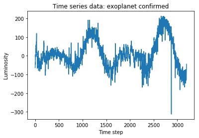

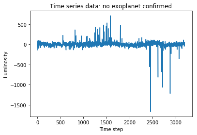

```python
plot_series(df_train.iloc[28, 1:], 'Time series data: exoplanet confirmed')
plot_series(df_train.iloc[37, 1:], 'Time series data: no exoplanet confirmed')
```

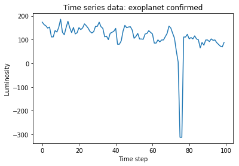

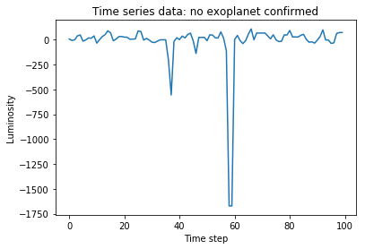

```python
plot_series(df_train.iloc[28, 2800:2900], 'Time series data: exoplanet confirmed')
plot_series(df_train.iloc[37, 2400:2500], 'Time series data: no exoplanet confirmed')
```

The top figure appears to show a transit at around x=2875. However, a sharp dip in brightness alone does not indicate a transit - as shown in Figure 2. The network will have to look for subtle features.

Feature normalization is important for the CNN to work properly.

```python
df_train_x = df_train.iloc[:, 1:]
df_test_x = df_test.iloc[:, 1:]

df_train_nm_x = pd.DataFrame(normalize(df_train_x.values))
df_train_y = df_train['LABEL'].values

x_test = normalize(df_test_x.values)
y_test = df_test['LABEL'].values
```

Plot the same data points after normalizing the data to make sure we didn't break anything

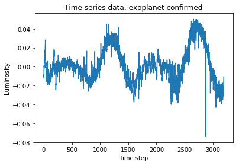

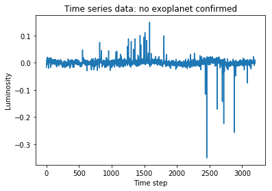

```python
plot_series(df_train_nm_x.iloc[28, 1:], 'Time series data: exoplanet confirmed')
plot_series(df_train_nm_x.iloc[37, 1:], 'Time series data: no exoplanet confirmed')
```

Now we have normalized the data we will augment the training set so it is not as badly imbalanced. I will use SMOTE to add more confirmed exoplantes to the normalized training set.

```python
X_t, X_CV, y_t, y_CV = train_test_split(df_train_nm_x, df_train_y, test_size=0.2, random_state=30, stratify=df_train_y)

sm = SMOTE(random_state=30, ratio=0.5)
X_resampled, y_resampled = SMOTE().fit_sample(X_t, y_t)
#X_resampled, y_resampled = X_t, y_t
num_stars = len(X_resampled)
training_exoplanets = 0
for item in y_resampled:
    if item == 1:
        training_exoplanets+=1

percent = (training_exoplanets / num_stars) * 100.
print('There are {0:2d} training flux records.'.format(num_stars))
print('There are %s confirmed non-exoplants in the training set' %training_exoplanets)
print('{0:2f}% of the records are confirmed exoplants\n'.format(percent))

num_stars = len(X_CV)
training_exoplanets = 0
for item in y_CV:
    if item == 1:
        training_exoplanets+=1

percent = (training_exoplanets / num_stars) * 100.
print('There are {0:2d} validation flux records.'.format(num_stars))
print('There are %s confirmed non-exoplants in the validation set' %training_exoplanets)
print('{0:2f}% of the records are confirmed exoplants\n'.format(percent))
```

```
There are 8078 training flux records.
There are 4039 confirmed non-exoplants in the training set
50.000000% of the records are confirmed exoplants

There are 1018 validation flux records.
There are 7 confirmed non-exoplants in the validation set
0.687623% of the records are confirmed exoplants
```

Train the model

```python
# we want a numpy array not a dataframe
X_CV = X_CV.values

# reshape for keras
X_resampled = X_resampled.reshape(X_resampled.shape[0], X_resampled.shape[1], 1)
X_CV = X_CV.reshape(X_CV.shape[0], X_CV.shape[1], 1)
x_test = x_test.reshape(x_test.shape[0], x_test.shape[1], 1)
```

```python
model = Sequential()
model.add(Conv1D(filters=16, kernel_size=3, activation='relu', input_shape=X_resampled.shape[1:]))
model.add(Conv1D(filters=32, kernel_size=5, activation='relu'))
model.add(Conv1D(filters=64, kernel_size=5, activation='relu'))
model.add(Conv1D(filters=128, kernel_size=5, activation='relu'))
model.add(Conv1D(filters=256, kernel_size=5, activation='relu'))
model.add(MaxPool1D(strides=2))
model.add(BatchNormalization())
model.add(Conv1D(filters=256, kernel_size=5, activation='relu'))
model.add(Conv1D(filters=128, kernel_size=5, activation='relu'))
model.add(Conv1D(filters=64, kernel_size=5, activation='relu'))
model.add(Conv1D(filters=32, kernel_size=5, activation='relu'))
model.add(Conv1D(filters=16, kernel_size=5, activation='relu'))
model.add(MaxPool1D(strides=2))
model.add(Flatten())
model.add(Dropout(0.5))
model.add(Dense(512, activation='relu'))
model.add(Dense(512, activation='relu'))
model.add(Dense(512, activation='relu'))
model.add(Dense(512, activation='relu'))
model.add(Dense(1, activation='sigmoid'))

model.summary()
```

```
_________________________________________________________________
Layer (type)                 Output Shape              Param #
=================================================================
conv1d_21 (Conv1D)           (None, 3195, 16)          64
_________________________________________________________________
conv1d_22 (Conv1D)           (None, 3191, 32)          2592
_________________________________________________________________
conv1d_23 (Conv1D)           (None, 3187, 64)          10304
_________________________________________________________________
conv1d_24 (Conv1D)           (None, 3183, 128)         41088
_________________________________________________________________
conv1d_25 (Conv1D)           (None, 3179, 256)         164096
_________________________________________________________________
max_pooling1d_5 (MaxPooling1 (None, 1589, 256)         0
_________________________________________________________________
batch_normalization_3 (Batch (None, 1589, 256)         1024
_________________________________________________________________
conv1d_26 (Conv1D)           (None, 1585, 256)         327936
_________________________________________________________________
conv1d_27 (Conv1D)           (None, 1581, 128)         163968
_________________________________________________________________
conv1d_28 (Conv1D)           (None, 1577, 64)          41024
_________________________________________________________________
conv1d_29 (Conv1D)           (None, 1573, 32)          10272
_________________________________________________________________
conv1d_30 (Conv1D)           (None, 1569, 16)          2576
_________________________________________________________________
max_pooling1d_6 (MaxPooling1 (None, 784, 16)           0
_________________________________________________________________
flatten_3 (Flatten)          (None, 12544)             0
_________________________________________________________________
dropout_3 (Dropout)          (None, 12544)             0
_________________________________________________________________
dense_11 (Dense)             (None, 512)               6423040
_________________________________________________________________
dense_12 (Dense)             (None, 512)               262656
_________________________________________________________________
dense_13 (Dense)             (None, 512)               262656
_________________________________________________________________
dense_14 (Dense)             (None, 512)               262656
_________________________________________________________________
dense_15 (Dense)             (None, 1)                 513
=================================================================
Total params: 7,976,465
Trainable params: 7,975,953
Non-trainable params: 512
_________________________________________________________________
```

```python
model.compile(optimizer=Adam(lr=1e-5), loss = 'binary_crossentropy', metrics=['accuracy'])
hist = model.fit(X_resampled, y_resampled, batch_size=64, epochs=50, verbose=1, validation_data=(X_CV, y_CV))
```

```
Train on 8078 samples, validate on 1018 samples
```

## Evaluate the model

```python
y_pred = model.predict(X_CV)
precision, recall, thresholds = precision_recall_curve(y_CV, y_pred, pos_label=1.)
auprc = auc(recall, precision)

print('AUPRC:', auprc)
accuracy_train = accuracy_score(y_CV, y_pred.round())
precision_train = precision_score(y_CV, y_pred.round())
recall_train = recall_score(y_CV, y_pred.round())
confusion_matrix_train = confusion_matrix(y_CV, y_pred.round())
classification_report_train = classification_report(y_CV, y_pred.round())
print(" ")
print("Train Set Error", 1.0 - accuracy_train)
print("------------")
print("Precision - Train Set", precision_train)
print("------------")
print("Recall - Train Set", recall_train)
print("------------")
print("Confusion Matrix - Train Set")
print(confusion_matrix_train)
print("------------")
print(" ")
print("------------")
print("classification_report_train")
print(classification_report_train)
```

```
AUPRC: 0.6075339058523491

Train Set Error 0.004911591355599265
------------
Precision - Train Set 0.6666666666666666
------------
Recall - Train Set 0.5714285714285714
------------
Confusion Matrix - Train Set
[[1009    2]
 [   3    4]]
------------

------------
classification_report_train
             precision    recall  f1-score   support

          0       1.00      1.00      1.00      1011
          1       0.67      0.57      0.62         7

avg / total       0.99      1.00      0.99      1018
```

Test set test scores

```python
y_pred = model.predict(x_test)
precision, recall, thresholds = precision_recall_curve(y_test, y_pred, pos_label=1.)
auprc = auc(recall, precision)
print('Test set performance')
print('AUPRC:', auprc)

accuracy_test = accuracy_score(y_test, y_pred.round())
precision_test = precision_score(y_test, y_pred.round())
recall_test = recall_score(y_test, y_pred.round())
confusion_matrix_test = confusion_matrix(y_test, y_pred.round())
classification_report_test = classification_report(y_test, y_pred.round())

print(" ")
print("Test Set Error", 1.0 - accuracy_test)
print("------------")
print("Precision - Test Set", precision_test)
print("------------")
print("Recall - Test Set", recall_test)
print("------------")
print("Confusion Matrix - Test Set")
print(confusion_matrix_test)
print("------------")
print(" ")
print("------------")
print("classification_report_test")
print(classification_report_test)
```

```
Test set performance
AUPRC: 0.6199638535861155

Test Set Error 0.0052631578947368585
------------
Precision - Test Set 0.75
------------
Recall - Test Set 0.6
------------
Confusion Matrix - Test Set
[[564   1]
 [  2   3]]
------------

------------
classification_report_test
             precision    recall  f1-score   support

          0       1.00      1.00      1.00       565
          1       0.75      0.60      0.67         5

avg / total       0.99      0.99      0.99       570
```

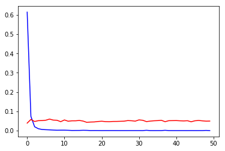

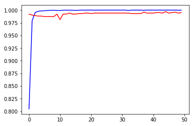

```python
plt.plot(hist.history['loss'], color='b')
plt.plot(hist.history['val_loss'], color='r')
plt.show()
plt.plot(hist.history['acc'], color='b')
plt.plot(hist.history['val_acc'], color='r')
plt.show()
```

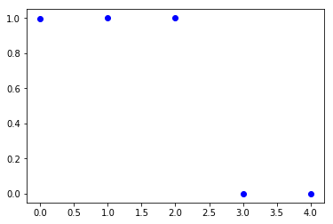

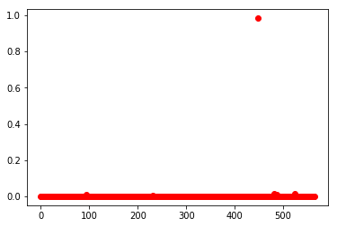

```python
non_idx = np.where(y_test == 0.)[0]
yes_idx = np.where(y_test == 1.)[0]

plt.plot([y_pred[i] for i in yes_idx], 'bo')
plt.show()
plt.plot([y_pred[i] for i in non_idx], 'ro')
plt.show()
```

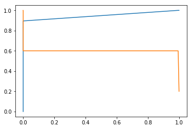

```
Crossover at 0.00 with specificity 0.83
```

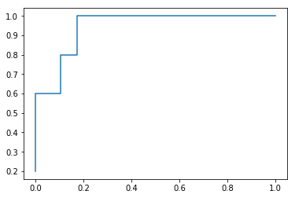

```
ROC area under curve is 0.94
```

```python
y_hat = model.predict(x_test)[:,0]
y_true = (y_test + 0.5).astype("int")

fpr, tpr, thresholds = roc_curve(y_true, y_hat)
plt.plot(thresholds, 1.-fpr)
plt.plot(thresholds, tpr)
plt.show()

crossover_index = np.min(np.where(1.-fpr <= tpr))
crossover_cutoff = thresholds[crossover_index]
crossover_specificity = 1.-fpr[crossover_index]
print("Crossover at {0:.2f} with specificity {1:.2f}".format(crossover_cutoff, crossover_specificity))
plt.plot(fpr, tpr)
plt.show()
print("ROC area under curve is {0:.2f}".format(roc_auc_score(y_true, y_hat)))
```

```
[452]
452
```

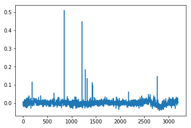

```python
false_positives = np.where(y_hat * (1. - y_test) > 0.5)[0]
print(false_positives)

for i in false_positives:
    if y_hat[i] > crossover_cutoff:
        print(i)
        plt.plot(x_test[i])
        plt.show()
```